# Project 1

Simon Kauppinen

# Chapter 3.7 Exercise 13

```r
set.seed(1)
```

a)-c)

```r
x <- rnorm(100) # Creates a sample from random normal distribution with n=100
eps <- rnorm(100,0,0.25)
y <- -1 + 0.5*x + eps
```

The length of *y* is 100, $\beta_0 = -1$, $\beta_1 = 0.5$.

d)

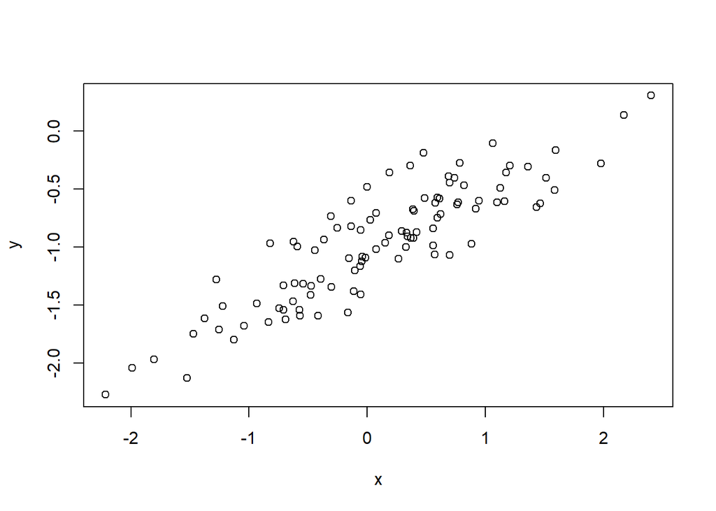

```r
plot(x,y)
```

e)

```r
lm.fit <- lm(y ~ x)
```

The method of least squares assumes a linear relationship between Y and X. Based on the scatter plot the assumption seems reasonable. Since there is only one independent variable we don’t need to check for multicollinearity or interaction.

```r
summary(lm.fit)
```

```
##
## Call:
## lm(formula = y ~ x)
##
## Residuals:
##      Min       1Q   Median       3Q      Max
## -0.46921 -0.15344 -0.03487  0.13485  0.58654
##
## Coefficients:
##             Estimate Std. Error t value Pr(>|t|)
## (Intercept) -1.00942    0.02425  -41.63   <2e-16 ***
## x            0.49973    0.02693   18.56   <2e-16 ***
## ---
## Signif. codes:  0 '***' 0.001 '**' 0.01 '*' 0.05 '.' 0.1 ' ' 1
##
## Residual standard error: 0.2407 on 98 degrees of freedom
## Multiple R-squared:  0.7784, Adjusted R-squared:  0.7762
## F-statistic: 344.3 on 1 and 98 DF,  p-value: < 2.2e-16
```

From the summary we that see the model explains 77.8% of the variance in the data ($R^2=0.7784$) with $p<2.2\cdot 10^{-16}$. We also see that both $\hat{\beta}_0 =$ -1.0094232 and $\hat{\beta}_1 =$ 0.4997349 are statistically significant with $p<2.2\cdot10^{-16}$ for both coefficients.

The estimated values look very close to the true values with $\|\hat{\beta}_0-\beta\|=0.00942$ and $\|\hat{\beta}_1-\beta_1\|=0.0003$. We can do a t-test to check if the differences are statistically significant, but without calculating the p-value I would guess that they are not for $\alpha=0.05$

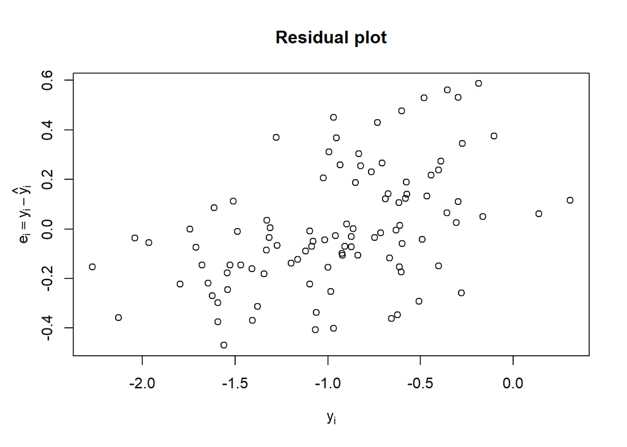

```r
res <- resid(lm.fit)
plot(y,res, main='Residual plot', xlab = TeX(r'($y_i$)'), ylab = '' )
title(ylab = TeX(r'($e_i=y_i-\hat{y}_i$)'), line=2.2)
```

The residuals look like they could be trending upwards suggesting that the data may be nonlinear.

f)

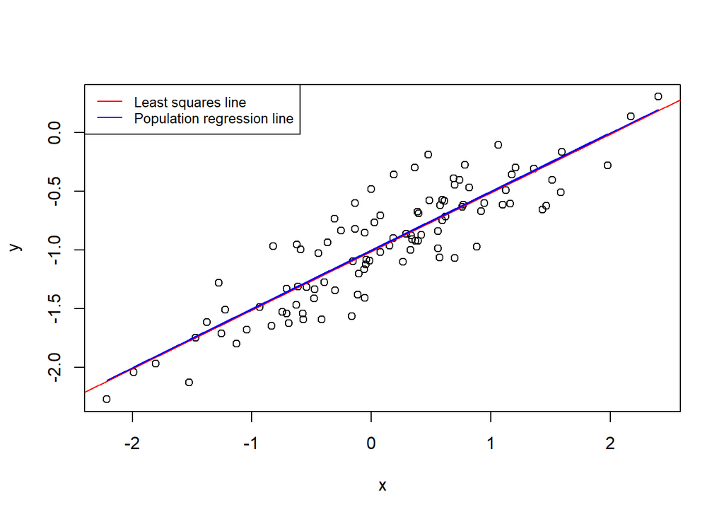

```r
plot(x,y)
abline(lm.fit, col='red')
lines(x,y-eps, col='blue')
legend("topleft", legend=c('Least squares line', 'Population regression line'), col=c('red','blue'), lty=1.1, cex=0.8)
```

g)

```r
xsquared <- x^2
lm2.fit <- lm(y~x + xsquared)
summary(lm2.fit)
```

```
##
## Call:
## lm(formula = y ~ x + xsquared)
##
## Residuals:
##     Min      1Q  Median      3Q     Max
## -0.4913 -0.1563 -0.0322  0.1451  0.5675
##
## Coefficients:
##             Estimate Std. Error t value Pr(>|t|)
## (Intercept) -0.98582    0.02941 -33.516   <2e-16 ***
## x            0.50429    0.02700  18.680   <2e-16 ***
## xsquared    -0.02973    0.02119  -1.403    0.164
## ---
## Signif. codes:  0 '***' 0.001 '**' 0.01 '*' 0.05 '.' 0.1 ' ' 1
##
## Residual standard error: 0.2395 on 97 degrees of freedom
## Multiple R-squared:  0.7828, Adjusted R-squared:  0.7784
## F-statistic: 174.8 on 2 and 97 DF,  p-value: < 2.2e-16
```

Here we can see that $P(\hat\beta_2=0)=0.164$ hence the observed values do not support including a second degree term in the model for $\alpha=0.05$.

# Chapter 4.8 Exercise 14

a)

```r
suppressWarnings(library("ISLR2"))
mpgmedian <- median(Auto[[1]])
mpg01 <- numeric(length(Auto$mpg)) # Creates a zero vector same length as Auto$mpg

for(i in 1:length(mpg01)){
  if (Auto[[1]][i] >= mpgmedian) {
    mpg01[i] = 1
  }
}

# Changes the i-th element in mpg01 to 1 if mpg[i] >= median of mpg

df <- data.frame (mpg01,Auto)
```

b)

```r
suppressWarnings(suppressMessages(library(DataExplorer)))
```

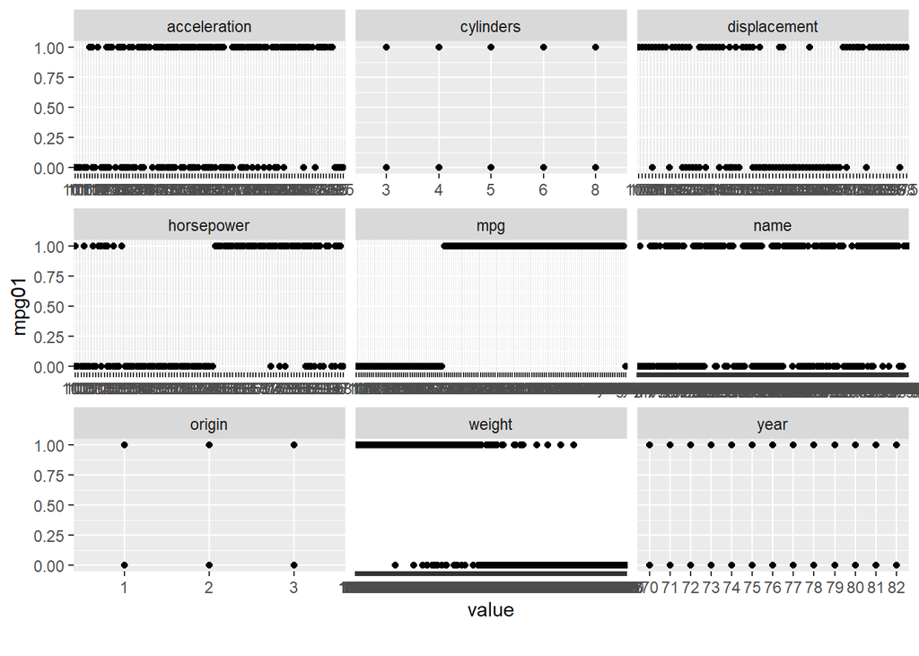

```r
suppressWarnings(plot_scatterplot(df, by = 'mpg01'))
```

Based on the scatter plot the features, excluding mpg, that seem most likely to be useful in predicting mpg01 are weight and horsepower.

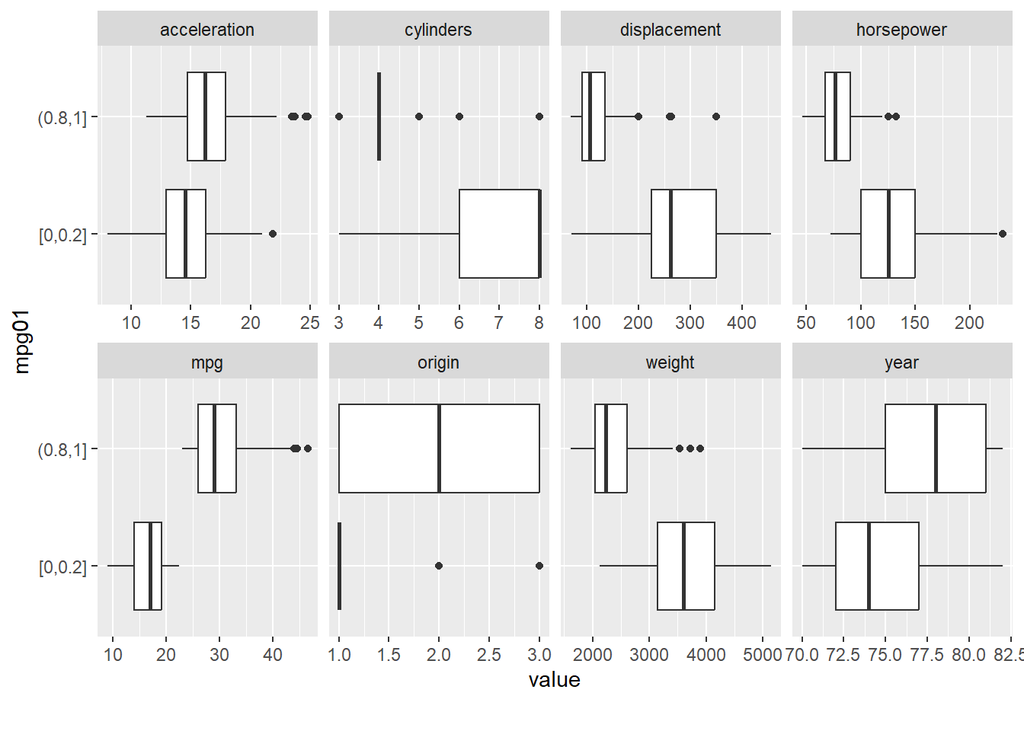

```r
plot_boxplot(df, by = 'mpg01')
```

Based on the box plots cylinders and displacement might also be useful in addition to weight and horsepower.

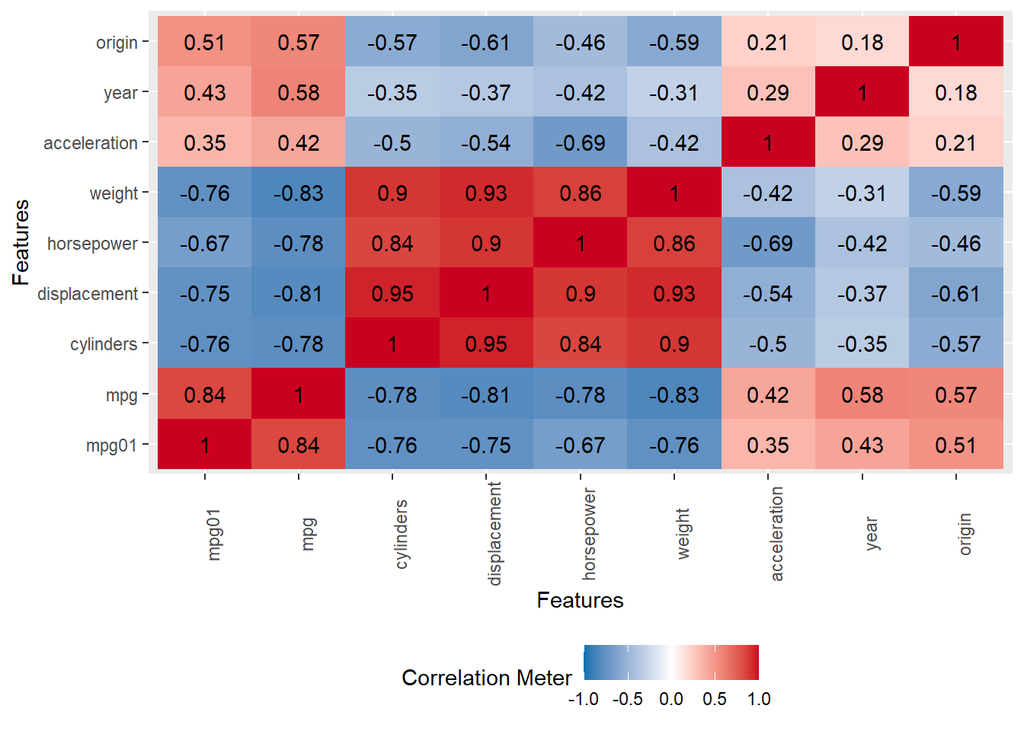

```r
suppressWarnings(plot_correlation(df))
```

Based on the correlation matrix the useful predictors would be weight, horsepower, displacement and number of cylinders.

c)

```r
predictors <- c("cylinders", "displacement", "horsepower", "weight")
set.seed(1)
training_index <- sample.int(nrow(df),300)
trainingdata <- df[training_index,]
testdata <- df[-training_index, predictors]
```

d)

```r
suppressMessages(library("MASS"))
```

```r
lda.fit <- lda(mpg01 ~ cylinders + displacement + horsepower + weight, data=trainingdata)

lda.pred <- predict(lda.fit, testdata)

lda.conf_mat <- table(True = df$mpg01[-training_index], Predicted=lda.pred$class)
#Confusion matrix

lda.testerror <- 1 - mean(df$mpg01[-training_index] == lda.pred$class)

# Error rate = 1 - rate of correct classifications

print(lda.conf_mat)
```

```
##     Predicted
## True  0  1
##    0 39 10
##    1  1 42
```

The test error of the LDA model is 0.1195652

e)

```r
qda.fit <- qda(mpg01 ~ cylinders + displacement + horsepower + weight, data=trainingdata)

qda.pred <- suppressWarnings(predict(qda.fit, testdata))

qda.conf_mat <- table(True = df$mpg01[-training_index], Predicted=qda.pred$class)

qda.testerror <- 1 - mean(df$mpg01[-training_index] == qda.pred$class)

print(qda.conf_mat)
```

```
##     Predicted
## True  0  1
##    0 42  7
##    1  3 40
```

The test error of the QDA model is 0.1086957

f)

```r
lr.fit <- glm(mpg01 ~ cylinders + displacement + horsepower + weight, data=trainingdata, family = 'binomial')

lr.probs <- suppressWarnings(predict(lr.fit, testdata, type='response'))
#P(Yhat=1|X)

lr.pred <- ifelse(lr.probs > 0.5, 1, 0)
#Classifies prediction probabilities as 1 if P(Yhat=1|X)>0.5 and 0 otherwise

lr.conf_mat <- table(True = df$mpg01[-training_index], Predicted=lr.pred)
#Confusion matrix

lr.testerror <- 1 - mean(df$mpg01[-training_index] == lr.pred)
#Test error
print(lr.conf_mat)
```

```
##     Predicted
## True  0  1
##    0 43  6
##    1  2 41
```

The test error of the logistic regression model is 0.0869565

# Chapter 5.4 Exercise 6

```r
set.seed(1)
```

```r
suppressWarnings(suppressMessages(library("ISLR2")))
```

```r
default <- Default$default
income <- Default$income
balance <- Default$balance


mlr.fit <- glm(default ~ income + balance, data=Default, family = 'binomial')

summary(mlr.fit)
```

```
##
## Call:
## glm(formula = default ~ income + balance, family = "binomial",
##     data = Default)
##
## Coefficients:
##               Estimate Std. Error z value Pr(>|z|)
## (Intercept) -1.154e+01  4.348e-01 -26.545  < 2e-16 ***
## income       2.081e-05  4.985e-06   4.174 2.99e-05 ***
## balance      5.647e-03  2.274e-04  24.836  < 2e-16 ***
## ---
## Signif. codes:  0 '***' 0.001 '**' 0.01 '*' 0.05 '.' 0.1 ' ' 1
##
## (Dispersion parameter for binomial family taken to be 1)
##
##     Null deviance: 2920.6  on 9999  degrees of freedom
## Residual deviance: 1579.0  on 9997  degrees of freedom
## AIC: 1585
##
## Number of Fisher Scoring iterations: 8
```

From the summary we can see that the estimated standard errors for income and balance are 4.985e-06, 2.274e-04 respectively

b)

```r
boot.fn <- function(dataset,index){
  default <- dataset$default
  income <- dataset$income
  balance <- dataset$balance
  lr.fit <- glm(default ~ income + balance, data=dataset[index,], family = 'binomial')
  return(coef(lr.fit)[2:3]) #Outputs coefficients for income and balance
}
```

c)

```r
suppressMessages(library(boot))
```

```r
set.seed(1)
boot.results <- boot(data=Default, statistic=boot.fn, R=1000) #

boot.standard_errors <- apply(boot.results$t, 2, sd) # boot.results$t is two long columns with coefficients, one for income one for balance. The 2 in the apply function calculates the std. error (sd) columnwise.

print(boot.standard_errors)
```

```
## [1] 4.866284e-06 2.298949e-04
```

The estimated standard error for income is 4.866e-06 and for balance 2.299e-04

# Chapter 6.6 Exercise 10

a)

```r
set.seed(1)
n=1000
p=20

X <- matrix(rnorm(n * p), nrow = n)
# Creates 1000x20 matrix with random values form the standard normal distribution

beta <- runif(p, -2, 2)
# Creates beta with random numbers from the uniform distribution
for (i in sample.int(20,4)) {
  beta[i] <- 0
}

#Turns four random values in beta to 0

epsilon <- rnorm(n, 0, 1)
Y <- X %*% beta + epsilon

data <- data.frame(Y = as.vector(Y), X)
```

b)

```r
training_set_index <- sample(1:n, 100)

training_set <- data[training_set_index,]
test_set <- data[-training_set_index,]
```

c)

```r
suppressWarnings(library(leaps))
```

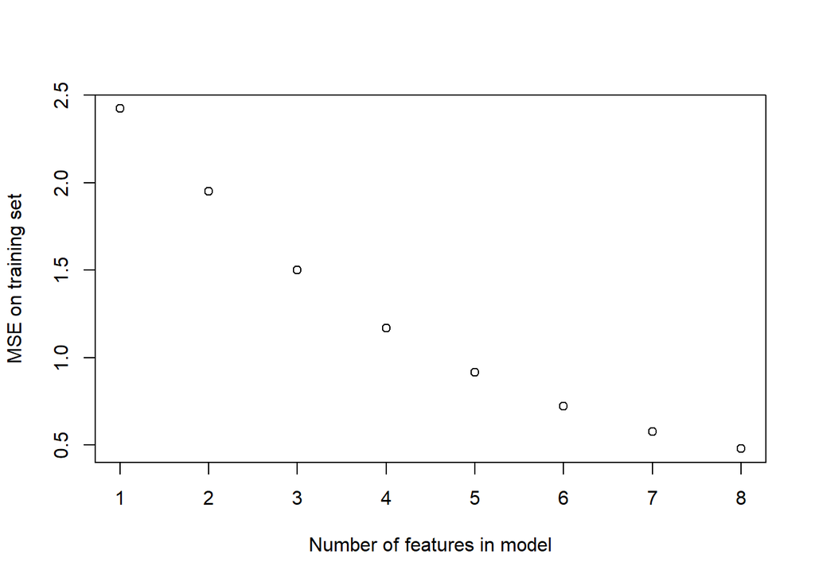

```r
regfit.full <- regsubsets(Y~.,training_set)
mse.training <- 1/n * summary(regfit.full)$rss
plot(1:8,mse.training, xlab = 'Number of features in model', ylab = 'MSE on training set')
```

d)

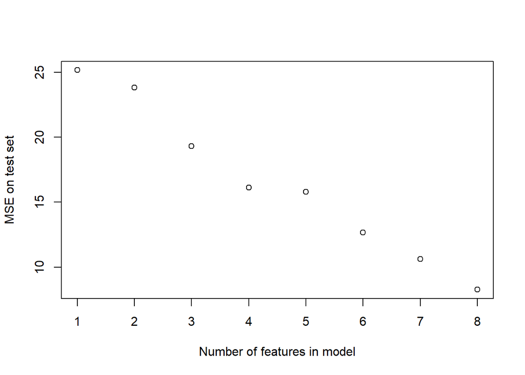

```r
mse.test <- numeric(8)

for (i in 1:8){
  betas <- coef(regfit.full, id=i) #Betas of best model with i features

  features <- names(betas)[-1] # Names of the features in best model with i features

  X <- as.matrix(test_set[,features, drop=FALSE])
  # Creates matrix with columns corresponding to best features

  X <- cbind("(Intercept)" = rep(1,nrow(X)),X)
  # Prepends a column with 1s to the matrix X to so each row in X is (1,x_0,...,x_i). Then we can do matrix multiplication of X and betas

  Yhat <- X%*%betas
  mse.test[i] <- 1/nrow(X) * sum( (test_set$Y - Yhat)^2 )
}

plot(1:8,mse.test, xlab= 'Number of features in model', ylab='MSE on test set')
```